# Scandal — Polêmica & Ficção

Matheus Alves

18 de julho de 2018

## Introdução

Scandal foi uma série de televisão estadunidense de thriller político criada por Shonda Rhimes. A série se passa em Washington D.C e conta a história de Olivia Pope, ex-funcionária da Casa Branca e responsável por uma empresa de gerenciamento de crises. No decorrer da série, a personagem principal salva as carreiras das principais figuras do centro do poder político estadunidense e, nesse percurso, se aproxima de se tornar a pessoa mais poderosa do mundo.

## Motivação

Durante sua exibição, Scandal manteve bons níveis de audiência e, em alguns momentos, ultrapassou os dez milhões de espectadores por episódio. Tamanho engajamento é, sem dúvidas, uma forte justificativa para análises sobre o comportamento do público em relação a essa série, mas não a única.

Ainda que se desenrole de maneira intimamente ligada ao Partido Republicano, Scandal aborda diversos temas tidos como progressistas durante sua história. Dentre esses temas, as questões de igualdade racial e de gênero são pontos importantes para compreender os personagens retratados. Entender como o público se comporta em relação a uma série que traz temas polêmicos para públicos conservadores foi a principal motivação para o desenvolvimento dessa análise.

Importando bibliotecas a serem utilizadas:

```r
library(readr)
library(dplyr)
```

```r
library(ggplot2)
```

Importando os dados do IMDB das avaliações referentes aos episódios de algumas séries da atualidade:

```r
series_imdb <- read_csv("../../database/series_from_imdb.csv")
series_imdb %>% glimpse()
```

```
## Observations: 3,326
## Variables: 18
## $ series_name <chr> "13 Reasons Why", "13 Reasons Why", "13 Reasons Wh...
## $ series_ep   <int> 1, 2, 3, 4, 5, 6, 7, 8, 9, 10, 11, 12, 13, 1, 2, 3...
## $ season      <int> 1, 1, 1, 1, 1, 1, 1, 1, 1, 1, 1, 1, 1, 1, 1, 1, 1,...
## $ url         <chr> "http://www.imdb.com/title/tt5174246/", "http://ww...
## $ Episode     <chr> "Tape 1, Side A", "Tape 1, Side B", "Tape 2, Side ...
## $ UserRating  <dbl> 8.5, 8.2, 8.2, 8.3, 8.5, 8.3, 8.6, 8.4, 8.9, 8.8, ...
## $ UserVotes   <dbl> 3624, 2977, 2757, 2632, 2588, 2463, 2512, 2403, 24...
## $ r1          <dbl> 0.04131093, 0.04154104, 0.04412297, 0.05039788, 0....
## $ r10         <dbl> 0.3288350, 0.2814070, 0.2896926, 0.3050398, 0.3447...
## $ r2          <dbl> 0.003855687, 0.003685092, 0.003254973, 0.002273588...
## $ r3          <dbl> 0.0033048747, 0.0046901173, 0.0047016275, 0.003031...
## $ r4          <dbl> 0.004681906, 0.006365159, 0.008318264, 0.005305040...
## $ r5          <dbl> 0.011291655, 0.013400335, 0.019529837, 0.016672982...
## $ r6          <dbl> 0.031120903, 0.035845896, 0.043761302, 0.038651004...
## $ r7          <dbl> 0.09115946, 0.13098827, 0.13309222, 0.11026904, 0....
## $ r8          <dbl> 0.20765629, 0.27805695, 0.28137432, 0.25653657, 0....
## $ r9          <dbl> 0.2767833, 0.2040201, 0.1721519, 0.2118227, 0.2448...
## $ season_ep   <int> 1, 2, 3, 4, 5, 6, 7, 8, 9, 10, 11, 12, 13, 1, 2, 3...
```

A título de curiosidade, as séries cujas avaliações estão disponíveis nos dados utilizados estão listadas abaixo:

```r
unique(series_imdb $ series_name)
```

```
##  [1] "13 Reasons Why"              "How to Get Away with Murder"
##  [3] "Mr Robot"                    "Sense8"
##  [5] "Sherlock"                    "Black Mirror"
##  [7] "Breaking Bad"                "Dexter"
##  [9] "House of Cards"              "Stranger Things"
## [11] "Arrow"                       "Gotham"
## [13] "Grey’s Anatomy"              "The 100"
## [15] "Agents of S.H.I.E.L.D."      "Daredevil"
## [17] "Flash"                       "Once Upon a Time"
## [19] "Friends"                     "Prison Break"
## [21] "Supernatural"                "The Blacklist"
## [23] "Homeland"                    "How I Met Your Mother"
## [25] "The Simpsons"                "Game of Thrones"
## [27] "Orphan Black"                "Scandal"
## [29] "The Walking Dead"            "Modern Family"
## [31] "Narcos"                      "Vikings"
```

## Análise

Uma vez que Scandal não só traz temas polêmicos, mas também se baseia neles para contar sua história, espera-se que o público tenha opiniões muito distintas sobre os episódios. Nesse cenário, as avaliações dos usuários do IMDB para os episódios da série serão altamente divergentes.

Para verificar esse comportamento, foram utilizadas as avaliações do usuários para os episódios da primeira à sexta temporadas de Scandal. No gráfico abaixo, cada temporada da série foi identificada por uma cor diferente e para as avaliações de seus episódios foram plotados boxplots e scatterplots sobrepostos.

Um **scatterplot** ou **diagrama de dispersão** utiliza coordenadas cartesianas para exibir valores de um conjunto de dados e é usado para verificar se existe relação de causa e efeito entre duas variáveis. No gráfico abaixo, cada episódio é representado por um ponto cuja posição no *eixo y* é definida por sua **média de avaliações** e cuja posição do *eixo x* é definida pela **temporada** a que pertence.

Um **boxplot** ou **diagrama de caixa** é uma ferramenta gráfica para representar a variação de dados observados. A caixa do diagrama engloba metade das observações e sua linha horizontal interna representa a mediana dos dados utilizados. Ainda, os pontos que se encontram além dos limites das linhas verticais do boxplot representam os *outliers*, os valores observados que destoam da tendência da amostra.

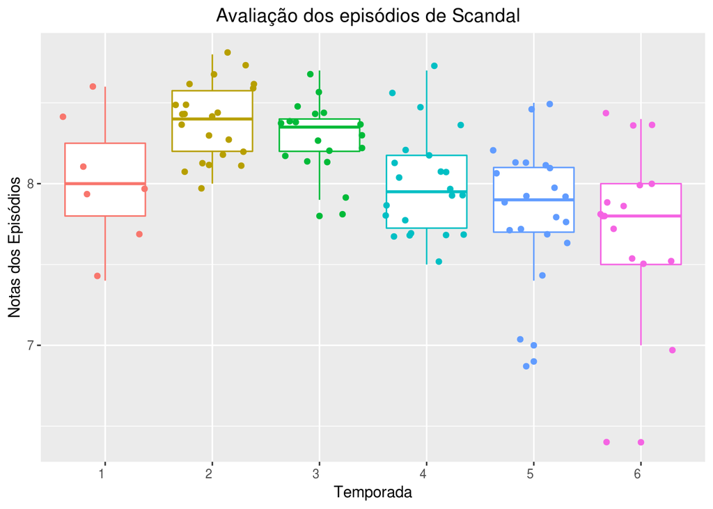

```r
scandalData <- series_imdb %>%
  filter(series_name %in% "Scandal")

ggplot(scandalData, aes(x = as.character(season), y = UserRating)) +
  geom_boxplot(aes(color = as.character(season)), show.legend=FALSE) +
  geom_jitter(aes(color = as.character(season)), show.legend=FALSE) +
  theme(axis.text.x = element_text(angle = 0, hjust = 1)) +
  ggtitle("\t\t\t\t Avaliação dos episódios de Scandal") +
  xlab("Temporada") + ylab("Notas dos Episódios")
```

A primeira observação possível para a visualização acima é que a temporada inicial de Scandal é de difícil comparação com suas sucessoras, uma vez que possui um número de episódios bem inferior a elas. Além disso, é notável como a presença de *outliers* se intensifica a medida que a história progride, principalmente nas temporadas mais recentes.

A frequência dos *outliers* também condiz com o *plot* da série, uma vez que, a partir da terceira temporada as questões de desigualdade racial tornam-se determinantes para a história e, a elas, se somam as questões de gênero a partir da quinta temporada.

## Conclusão

Em adendo, tornou-se perceptível que a presença dos *outliers* está associada ao decréscimo da mediana das avaliações dos episódios, mostrando que a abordagem de alguns temas tem relação com o quanto a série desagrada seu público.